# Documentation

### What is this?

This package contains a collection of functions I wrote as I was working on my Data Science projects. They perform some tedious and repetitive operations that are necessary when making Machine Learning models. These functions builds on top of popular libraries such as: numpy, pandas, matplot.lib, sklearn.

#### Some functionalities:

- Find all outliers within a dataframe.
- Perform EDA on numerical variables
- Perform EDA on categorical variables
- Convert all of your categorical variables into dummy variables
- Perform feature selection using RFECV, SelectKBest, Lasso all at the same time, output results for comparison.

```python
import pandas as pd
import numpy as np
```

### cLiML.eda.findOutlier

This method will find all the outliers of the numerical variables within a DataFrame. Don't worry about any columns that are of Object type. This method will automatically ignore those columns.

#### input:

- DataFrame: Takes a dataframe.

#### Example

```python
# First import the package
from cLiML import eda

# Import our data
df = pd.read_csv('housing.csv')
df.head()
```

|  | Id | MSSubClass | MSZoning | LotFrontage | LotArea | Street | Alley | LotShape | LandContour | Utilities | ... | PoolArea | PoolQC | Fence | MiscFeature | MiscVal | MoSold | YrSold | SaleType | SaleCondition | SalePrice |
| --- | --- | --- | --- | --- | --- | --- | --- | --- | --- | --- | --- | --- | --- | --- | --- | --- | --- | --- | --- | --- | --- |
| 0 | 1 | 60 | RL | 65.0 | 8450 | Pave | NaN | Reg | Lvl | AllPub | ... | 0 | NaN | NaN | NaN | 0 | 2 | 2008 | WD | Normal | 208500 |
| 1 | 2 | 20 | RL | 80.0 | 9600 | Pave | NaN | Reg | Lvl | AllPub | ... | 0 | NaN | NaN | NaN | 0 | 5 | 2007 | WD | Normal | 181500 |
| 2 | 3 | 60 | RL | 68.0 | 11250 | Pave | NaN | IR1 | Lvl | AllPub | ... | 0 | NaN | NaN | NaN | 0 | 9 | 2008 | WD | Normal | 223500 |
| 3 | 4 | 70 | RL | 60.0 | 9550 | Pave | NaN | IR1 | Lvl | AllPub | ... | 0 | NaN | NaN | NaN | 0 | 2 | 2006 | WD | Abnorml | 140000 |
| 4 | 5 | 60 | RL | 84.0 | 14260 | Pave | NaN | IR1 | Lvl | AllPub | ... | 0 | NaN | NaN | NaN | 0 | 12 | 2008 | WD | Normal | 250000 |

5 rows × 81 columns

```python
# perform the method on two numerical columns
print(eda.findOutlier(df[['SalePrice', 'LotArea']]))
```

[output not shown]

```python
# perform the method on a numerical column and an object column.
# Note how the object column is automatically ignored.
print(eda.findOutlier(df[['LotFrontage', 'Street']]))
```

```
{'LotFrontage': [112.0, 115.0, 24.0, 21.0, 121.0, 122.0, 120.0, 134.0, 141.0, 174.0, 129.0, 140.0, 118.0, 116.0, 150.0, 130.0, 137.0, 144.0, 114.0, 128.0, 149.0, 313.0, 168.0, 182.0, 138.0, 160.0, 152.0, 124.0, 153.0]}
```

### cLiML.eda.edaCategorical

This method will plot each categorical variables against the target variable as a bar graph. Note that the target variable is aggregated using either a 'median' or 'mean' method. Effectivly what we are doing is df.groupby(category).target.mean() or df.groupby(category).target.median()

Note, this will be performed for every column, regardless if they are Object or Numbers. So if you don't want to analyse your number variables as a categorical variable, make sure to exclude those columns.

Plots will be presented in two columns of subplots.

#### input:

- df: The dataframe you want to analyze.
- target: The name of your target variable, note this must be a string.
- aggre = 'median': The default aggregate function is median, type 'mean' if you want mean.
- max_y_axis = None: This is the maximum y axis value you want. If left blank, it will automatically use the maximum value of your target variable.

#### Example

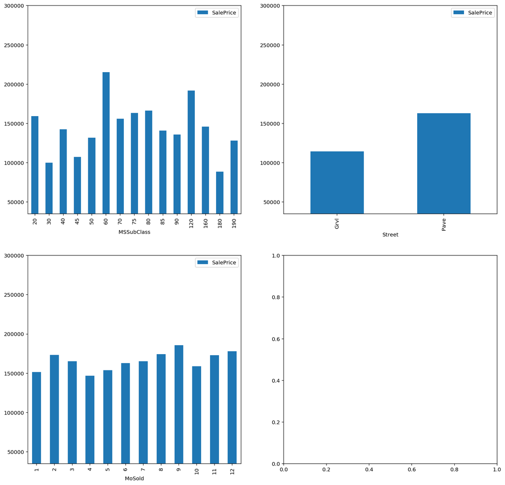

```python
# Import the method, remember to also include matplotlib inline
from cLiML import eda
%config InlineBackend.figure_format = 'retina'
%matplotlib inline

# Note that the aggregate function is not selected, so median is used by default
#
eda.edaCategorical(df[['MSSubClass', 'Street', 'SalePrice','MoSold']], target = 'SalePrice', max_y_axis = 300000)
```

### cLiML.eda.edaContinuous

This method will plot each continuous variables against the target variable as a scatter plot.

Note, this method will automatically recognize numeric columns. Object columns are automatically ignored.

Plots will be presented in two columns of subplots.

#### input:

- df: The dataframe you want to analyze.
- target: The name of your target variable, note this must be a string.
- max_y_axis = None: This is the maximum y axis value you want. If left blank, it will automatically use the maximum value of your target variable.

#### Example

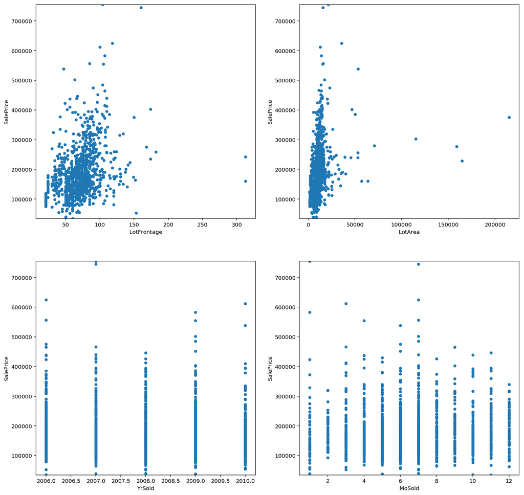

```python
# Import the method, remember to also include matplotlib inline
from cLiML import eda
%config InlineBackend.figure_format = 'retina'
%matplotlib inline


#
eda.edaContinuous(df[['Street', 'SalePrice', 'LotFrontage','LotArea', 'YrSold', 'MoSold']], target = 'SalePrice')
```

### cLiML.model_prep.dummify

This method will dummify all the Object type variables in your dataframe. You can also specify exactly which columns you want to get dummified. Note if you want a numerical column to be dummmified, you must specify it.

#### input:

- df: Your dataframe
- categorical_var = None: By default, all Object type columns will be dummified. Or you can input a list of column names that you want to get dummified.

#### Example

```python
# Note only the street type is dummified, as it is the only Object type column
from cLiML import model_prep
model_prep.dummify(df[['MSSubClass', 'Street', 'SalePrice','MoSold']]).head()
```

|  | MSSubClass | SalePrice | MoSold | Street_Grvl |
| --- | --- | --- | --- | --- |
| 0 | 60 | 208500 | 2 | 0 |
| 1 | 20 | 181500 | 5 | 0 |
| 2 | 60 | 223500 | 9 | 0 |
| 3 | 70 | 140000 | 2 | 0 |
| 4 | 60 | 250000 | 12 | 0 |

```python
# Both 'MoSold' and 'Street' are dummified
from cLiML import model_prep
model_prep.dummify(df[['MSSubClass', 'Street', 'SalePrice','MoSold']], categorical_var = ['MoSold', 'Street']).head()
```

|  | MSSubClass | SalePrice | MoSold_1 | MoSold_2 | MoSold_3 | MoSold_4 | MoSold_5 | MoSold_6 | MoSold_7 | MoSold_8 | MoSold_9 | MoSold_10 | MoSold_11 | Street_Grvl |
| --- | --- | --- | --- | --- | --- | --- | --- | --- | --- | --- | --- | --- | --- | --- |
| 0 | 60 | 208500 | 0 | 1 | 0 | 0 | 0 | 0 | 0 | 0 | 0 | 0 | 0 | 0 |
| 1 | 20 | 181500 | 0 | 0 | 0 | 0 | 1 | 0 | 0 | 0 | 0 | 0 | 0 | 0 |
| 2 | 60 | 223500 | 0 | 0 | 0 | 0 | 0 | 0 | 0 | 0 | 1 | 0 | 0 | 0 |
| 3 | 70 | 140000 | 0 | 1 | 0 | 0 | 0 | 0 | 0 | 0 | 0 | 0 | 0 | 0 |
| 4 | 60 | 250000 | 0 | 0 | 0 | 0 | 0 | 0 | 0 | 0 | 0 | 0 | 0 | 0 |

### cLiML.model_prep.feature_select_linear_reg

This will perform RFECV, SelectKBest, Lasso feature selection on your dataframe, assuming you are going to perform a linear regression.

The results of all 3 feature selections are outputted side by side for comparison.

#### input:

- X: Takes a 2D dataframe.
- y: Takes a 1D series.
- cv: The number of cross validation fold you want to perform

#### Example

```python
data = pd.read_csv('data.csv').drop(columns = ['Unnamed: 0'])
```

```python
data.head()
```

|  | Id | FrontStreetFeet | LandArea | OverallQual | OverallCond | YearBuilt | YearRemodAdd | MasVnrArea | BsmtFinArea1 | BsmtFinArea2 | ... | MoSold_6 | MoSold_7 | MoSold_8 | MoSold_9 | MoSold_10 | MoSold_11 | YrSold_2006 | YrSold_2007 | YrSold_2008 | YrSold_2009 |
| --- | --- | --- | --- | --- | --- | --- | --- | --- | --- | --- | --- | --- | --- | --- | --- | --- | --- | --- | --- | --- | --- |
| 0 | 1 | 65.0 | 8450 | 7 | 5 | 2003 | 2003 | 196.0 | 706 | 0 | ... | 0 | 0 | 0 | 0 | 0 | 0 | 0 | 0 | 1 | 0 |
| 1 | 2 | 80.0 | 9600 | 6 | 8 | 1976 | 1976 | 0.0 | 978 | 0 | ... | 0 | 0 | 0 | 0 | 0 | 0 | 0 | 1 | 0 | 0 |
| 2 | 3 | 68.0 | 11250 | 7 | 5 | 2001 | 2002 | 162.0 | 486 | 0 | ... | 0 | 0 | 0 | 1 | 0 | 0 | 0 | 0 | 1 | 0 |
| 3 | 4 | 60.0 | 9550 | 7 | 5 | 1915 | 1970 | 0.0 | 216 | 0 | ... | 0 | 0 | 0 | 0 | 0 | 0 | 1 | 0 | 0 | 0 |
| 4 | 5 | 84.0 | 14260 | 8 | 5 | 2000 | 2000 | 350.0 | 655 | 0 | ... | 0 | 0 | 0 | 0 | 0 | 0 | 0 | 0 | 1 | 0 |

5 rows × 283 columns

```python
from cLiML import model_prep

y = data['SalePrice']
X = data.drop(columns = ['SalePrice'])

model_prep.feature_select_linear_reg(X, y)
```

[output not shown]

|  | variable_RFECV | support | ranking | variable_skb | score | Variable_Lasso | Coefficients | CoeffAbs |
| --- | --- | --- | --- | --- | --- | --- | --- | --- |
| 0 | MasVnrType_BrkCmn | True | 1 | OverallQual | 2555.875482 | AboveGradeLiveArea | 24426.131871 | 24426.131871 |
| 1 | BsmtFinType2_Rec | True | 1 | AboveGradeLiveArea | 1408.920227 | OverallQual | 9646.348073 | 9646.348073 |
| 2 | Heating_Floor | True | 1 | GarageCars | 1009.527654 | TotalBsmtSF | 7942.622698 | 7942.622698 |
| 3 | Heating_GasA | True | 1 | TotalBsmtSF | 996.258884 | YearBuilt | 7752.830892 | 7752.830892 |
| 4 | Heating_GasW | True | 1 | GarageArea | 982.511930 | BsmtFinArea1 | 6408.646904 | 6408.646904 |
| 5 | Heating_Grav | True | 1 | 1stFlrArea | 927.204164 | KitchenQual_Ex | 5464.885965 | 5464.885965 |
| 6 | Heating_OthW | True | 1 | BsmtHeight_Ex | 624.390529 | BsmtExposure_Gd | 5107.766287 | 5107.766287 |
| 7 | HeatingQC_Ex | True | 1 | FullBath | 617.078388 | Neighborhood_StoneBr | 5106.195452 | 5106.195452 |
| 8 | HeatingQC_Fa | True | 1 | YearBuilt | 564.733772 | ExterQual_Ex | 5024.719517 | 5024.719517 |
| 9 | HeatingQC_Gd | True | 1 | RoomsAboveGrade | 563.281309 | BldgType_1Fam | 4935.124398 | 4935.124398 |
| 10 | HeatingQC_Po | True | 1 | YearRemodAdd | 513.387137 | SaleType_New | 4898.928061 | 4898.928061 |
| 11 | CentralAir_N | True | 1 | Foundation_PConc | 498.113520 | OverallCond | 4896.482762 | 4896.482762 |
| 12 | Electrical_FuseA | True | 1 | KitchenQual_Ex | 474.650618 | BsmtHeight_Ex | 4666.293396 | 4666.293396 |
| 13 | Electrical_FuseF | True | 1 | MasVnrArea | 447.255980 | Neighborhood_NridgHt | 4608.159553 | 4608.159553 |
| 14 | Electrical_FuseP | True | 1 | FireplaceQu_NA | 416.773654 | GarageQual_Ex | 4572.079025 | 4572.079025 |
| 15 | Electrical_Mix | True | 1 | ExterQual_Gd | 408.926540 | Neighborhood_Crawfor | 4090.307548 | 4090.307548 |
| 16 | Electrical_NA | True | 1 | Fireplaces | 391.542697 | GarageCars | 4053.138457 | 4053.138457 |
| 17 | KitchenQual_Ex | True | 1 | ExterQual_Ex | 383.644635 | Neighborhood_NoRidge | 4047.473696 | 4047.473696 |
| 18 | GarageType_2Types | True | 1 | Neighborhood_NridgHt | 349.479664 | LandArea | 3099.882866 | 3099.882866 |
| 19 | FireplaceQu_Po | True | 1 | HeatingQC_Ex | 340.719554 | ExteriorCover1_BrkFace | 2826.116382 | 2826.116382 |
| 20 | FireplaceQu_NA | True | 1 | BsmtFinType1_GLQ | 335.603848 | GarageCond_Ex | -2815.644569 | 2815.644569 |
| 21 | FireplaceQu_Gd | True | 1 | GarageFinish_Fin | 288.138392 | MasVnrArea | 2758.346505 | 2758.346505 |
| 22 | FireplaceQu_Fa | True | 1 | SaleType_New | 271.172076 | BedroomAbvGr | -2119.764500 | 2119.764500 |
| 23 | FireplaceQu_Ex | True | 1 | MasVnrType_None | 252.238903 | KitchenAbvGr | -2052.028096 | 2052.028096 |
| 24 | BsmtFinType2_NA | True | 1 | LandArea | 247.631673 | SaleCondition_Abnorml | -1996.210320 | 1996.210320 |
| 25 | Functional_Sev | True | 1 | BsmtFinArea1 | 240.922874 | GarageArea | 1907.836102 | 1907.836102 |
| 26 | Functional_Min2 | True | 1 | BuildingClass_60 | 203.078194 | BsmtFinType1_GLQ | 1888.195165 | 1888.195165 |
| 27 | Functional_Min1 | True | 1 | FireplaceQu_Gd | 202.618249 | YearRemodAdd | 1880.427667 | 1880.427667 |
| 28 | Functional_Maj2 | True | 1 | GarageType_Detchd | 201.067150 | ProxiToRoadRail1_Norm | 1801.561086 | 1801.561086 |
| 29 | Functional_Maj1 | True | 1 | FrontStreetFeet | 200.659032 | RoomsAboveGrade | 1775.554772 | 1775.554772 |
| ... | ... | ... | ... | ... | ... | ... | ... | ... |
| 252 | ProxiToRoadRail1_RRAe | True | 1 | YrSold_2007 | 0.387833 | HeatingQC_Gd | -0.000000 | 0.000000 |
| 253 | ProxiToRoadRail2_PosA | True | 1 | BsmtFinArea2 | 0.359167 | HeatingQC_Po | 0.000000 | 0.000000 |
| 254 | ProxiToRoadRail1_PosN | True | 1 | ExteriorCover2_Stone | 0.340583 | CentralAir_N | 0.000000 | 0.000000 |
| 255 | ProxiToRoadRail1_Norm | True | 1 | BuildingClass_40 | 0.333916 | Electrical_FuseA | 0.000000 | 0.000000 |
| 256 | ProxiToRoadRail1_Feedr | True | 1 | ProxiToRoadRail2_RRAn | 0.296923 | Electrical_FuseF | 0.000000 | 0.000000 |
| 257 | ProxiToRoadRail1_Artery | True | 1 | ExterCond_Ex | 0.296701 | Electrical_FuseP | 0.000000 | 0.000000 |
| 258 | Neighborhood_Timber | True | 1 | RoofMatl_Roll | 0.295544 | Electrical_Mix | 0.000000 | 0.000000 |
| 259 | Neighborhood_StoneBr | True | 1 | Utilities_AllPub | 0.288337 | Electrical_NA | 0.000000 | 0.000000 |
| 260 | Neighborhood_Somerst | True | 1 | LowQualFinArea | 0.219125 | LotConfig_Corner | 0.000000 | 0.000000 |
| 261 | ProxiToRoadRail1_PosA | True | 1 | LandContour_Low | 0.167518 | BsmtFinType2_LwQ | -0.000000 | 0.000000 |
| 262 | RoofStyle_Mansard | True | 1 | YrSold_2009 | 0.131720 | BsmtFinType2_BLQ | -0.000000 | 0.000000 |
| 263 | ProxiToRoadRail2_PosN | True | 1 | LotConfig_Corner | 0.087876 | Neighborhood_Blmngtn | 0.000000 | 0.000000 |
| 264 | ProxiToRoadRail2_RRAn | True | 1 | RoofMatl_Tar&Grv | 0.067861 | Foundation_Stone | -0.000000 | 0.000000 |
| 265 | RoofStyle_Gambrel | True | 1 | ProxiToRoadRail1_RRNe | 0.059977 | MasVnrType_None | -0.000000 | 0.000000 |
| 266 | RoofStyle_Gable | True | 1 | ProxiToRoadRail1_RRAn | 0.054404 | Neighborhood_MeadowV | -0.000000 | 0.000000 |
| 267 | RoofStyle_Flat | True | 1 | MoSold_10 | 0.035358 | ExterCond_Fa | 0.000000 | 0.000000 |
| 268 | HouseStyle_SFoyer | True | 1 | ProxiToRoadRail2_RRAe | 0.026604 | ExterCond_Po | 0.000000 | 0.000000 |
| 269 | HouseStyle_2Story | True | 1 | SaleType_CWD | 0.023274 | Foundation_CBlock | -0.000000 | 0.000000 |
| 270 | HouseStyle_2.5Unf | True | 1 | LotConfig_FR2 | 0.021843 | Neighborhood_IDOTRR | 0.000000 | 0.000000 |
| 271 | ProxiToRoadRail2_RRAe | True | 1 | Electrical_NA | 0.018743 | Foundation_Slab | 0.000000 | 0.000000 |
| 272 | HouseStyle_2.5Fin | True | 1 | MiscFeature_Gar2 | 0.017523 | BsmtHeight_Fa | 0.000000 | 0.000000 |
| 273 | HouseStyle_1.5Unf | True | 1 | FenceQual_GdPrv | 0.014741 | Neighborhood_Blueste | 0.000000 | 0.000000 |
| 274 | HouseStyle_1.5Fin | True | 1 | RoofStyle_Mansard | 0.009807 | BsmtHeight_Gd | -0.000000 | 0.000000 |
| 275 | BldgType_Twnhs | True | 1 | GarageCond_Gd | 0.007527 | Neighborhood_CollgCr | 0.000000 | 0.000000 |
| 276 | BldgType_Duplex | True | 1 | BsmtFinType2_GLQ | 0.004839 | BsmtCond_Po | 0.000000 | 0.000000 |
| 277 | BldgType_2fmCon | True | 1 | RoofStyle_Flat | 0.003406 | Neighborhood_BrDale | 0.000000 | 0.000000 |
| 278 | BldgType_1Fam | True | 1 | RoofMatl_Metal | 0.000886 | BsmtExposure_NA | 0.000000 | 0.000000 |
| 279 | HouseStyle_1Story | True | 1 | Foundation_Stone | 0.000612 | BsmtFinType1_ALQ | -0.000000 | 0.000000 |
| 280 | LandArea | False | 2 | MoSold_2 | 0.000464 | BsmtFinType1_BLQ | 0.000000 | 0.000000 |
| 281 | Id | False | 3 | SaleCondition_Alloca | 0.000138 | Id | -0.000000 | 0.000000 |

282 rows × 8 columns